# Introduction to Single Cell Analysis: COVID-19 Edition

Dr. Elana Fertig, Spring 2020

### Week 1 Session 2

### Obtaining Data

Step-by-step analysis: Gubin, Matthew M et al. “High-Dimensional Analysis Delineates Myeloid and Lymphoid Compartment Remodeling during Successful Immune-Checkpoint Cancer Therapy.” Cell 175.4 (2018): 1014-1030.e19.

#### Load Packages

```r
library(GEOquery)
library(plyr)
library(Matrix)
library(Seurat)
library(ggplot2)
library(cowplot)
library(SAVER)
```

#### Access Raw Data from GEO

```r
filePaths = getGEOSuppFiles("GSE119352")
filePaths
```

|  | size | isdir | mode | mtime | ctime | atime | uid | gid | uname | grname |
| --- | --- | --- | --- | --- | --- | --- | --- | --- | --- | --- |
| /Users/melanie/SingleCellCourse/GSE119352/GSE119352_RAW.tar | 56268800 | FALSE | 644 | 2020-05-12 08:51:26 | 2020-05-12 08:51:26 | 2020-05-12 08:50:32 | 502 | 20 | melanie | staff |
| /Users/melanie/SingleCellCourse/GSE119352/GSE119352_README.txt | 334 | FALSE | 644 | 2020-05-12 08:51:27 | 2020-05-12 08:51:27 | 2020-05-12 08:51:26 | 502 | 20 | melanie | staff |
| /Users/melanie/SingleCellCourse/GSE119352/GSE119352_scRNA_lymphoid_meta_data.tsv.gz | 125966 | FALSE | 644 | 2020-05-12 08:51:28 | 2020-05-12 08:51:28 | 2020-05-12 08:51:27 | 502 | 20 | melanie | staff |
| /Users/melanie/SingleCellCourse/GSE119352/GSE119352_scRNAseq_CD45_meta_data.tsv.gz | 356962 | FALSE | 644 | 2020-05-12 08:51:28 | 2020-05-12 08:51:28 | 2020-05-12 08:51:28 | 502 | 20 | melanie | staff |

```r
tarF <- list.files(path = "./GSE119352/", pattern = "*.tar", full.names = TRUE)
tarF
```

```
## [1] "./GSE119352//GSE119352_RAW.tar"
```

```r
untar(tarF, exdir = "./GSE119352/")
```

Get all of the zip files

```r
gzipF <- list.files(path = "./GSE119352/", pattern = "*.gz", full.names = TRUE)
gzipF
```

```
##  [1] "./GSE119352//GSE119352_scRNA_lymphoid_meta_data.tsv.gz"
##  [2] "./GSE119352//GSE119352_scRNAseq_CD45_meta_data.tsv.gz"
##  [3] "./GSE119352//GSM3371684_Control_barcodes.tsv.gz"
##  [4] "./GSE119352//GSM3371684_Control_genes.tsv.gz"
##  [5] "./GSE119352//GSM3371684_Control_matrix.mtx.gz"
##  [6] "./GSE119352//GSM3371685_aPD1_barcodes.tsv.gz"
##  [7] "./GSE119352//GSM3371685_aPD1_genes.tsv.gz"
##  [8] "./GSE119352//GSM3371685_aPD1_matrix.mtx.gz"
##  [9] "./GSE119352//GSM3371686_aCTLA4_barcodes.tsv.gz"
## [10] "./GSE119352//GSM3371686_aCTLA4_genes.tsv.gz"
## [11] "./GSE119352//GSM3371686_aCTLA4_matrix.mtx.gz"
## [12] "./GSE119352//GSM3371687_aPD1-aCTLA4_barcodes.tsv.gz"
## [13] "./GSE119352//GSM3371687_aPD1-aCTLA4_genes.tsv.gz"
## [14] "./GSE119352//GSM3371687_aPD1-aCTLA4_matrix.mtx.gz"
```

Unzip all your files

```r
ldply(.data = gzipF, .fun = gunzip)
```

| V1 |
| --- |
| 315325 |
| 914909 |
| 65280 |
| 740390 |
| 60731883 |
| 58480 |
| 740390 |
| 50203190 |
| 57324 |
| 740390 |
| 49736116 |
| 67422 |
| 740390 |
| 52857101 |

#### Read and Format Data

Read in matrix count data in matrixmarket format

```r
control_matrix <- readMM(file = './GSE119352/GSM3371684_Control_matrix.mtx')
class(control_matrix)
```

```
## [1] "dgTMatrix"
## attr(,"package")
## [1] "Matrix"
```

```r
control_matrix <- as.matrix(control_matrix)
```

Check matrix

```r
control_matrix[1:5,1:5]
```

```
##      [,1] [,2] [,3] [,4] [,5]
## [1,]    0    0    0    0    0
## [2,]    0    0    0    0    0
## [3,]    0    0    0    0    0
## [4,]    0    0    0    0    0
## [5,]    0    0    0    0    0
```

Check matrix dimensions

```r
dim(control_matrix)
```

```
## [1] 27998  3840
```

Read in gene names

```r
control_genes <- read.table(file = './GSE119352/GSM3371684_Control_genes.tsv',
                            sep = '\t', header = FALSE, stringsAsFactors = FALSE)
```

Check dimensions

```r
dim(control_genes)
```

```
## [1] 27998     2
```

Set gene short names to rownames of matrix

```r
rownames(control_matrix) <- control_genes[,2]
```

Check new rownames

```r
control_matrix[1:5,1:5]
```

```
##         [,1] [,2] [,3] [,4] [,5]
## Xkr4       0    0    0    0    0
## Gm1992     0    0    0    0    0
## Gm37381    0    0    0    0    0
## Rp1        0    0    0    0    0
## Rp1        0    0    0    0    0
```

Read in sample names

```r
control_barcodes <- read.table(file = './GSE119352/GSM3371684_Control_barcodes.tsv',
                               sep = '\t', header = FALSE, stringsAsFactors = FALSE)
```

Check matrix dimensions

```r
dim(control_barcodes)
```

```
## [1] 3840    1
```

Set barcodes to colnames of matrix

```r
colnames(control_matrix) <- control_barcodes[,1]
```

Check new colnames

```r
control_matrix[1:5,1:5]
```

```
##         AAACATACAGCGTT-1 AAACATACATTTCC-1 AAACATACCCAACA-1 AAACATACCCTTGC-1
## Xkr4                   0                0                0                0
## Gm1992                 0                0                0                0
## Gm37381                0                0                0                0
## Rp1                    0                0                0                0
## Rp1                    0                0                0                0
##         AAACATACGGGTGA-1
## Xkr4                   0
## Gm1992                 0
## Gm37381                0
## Rp1                    0
## Rp1                    0
```

Add unique identifier to colnames

```r
colnames(control_matrix) <- paste(colnames(control_matrix), "control", sep = "_")
```

pData for treatment

```r
control_pdat <- data.frame("samples" = colnames(control_matrix), "treatment" = "control")
```

**Repeat steps above for remaining treatments and merge matrices**

Read in matrix count data

```r
aPD1_matrix <- readMM(file = './GSE119352/GSM3371685_aPD1_matrix.mtx')
aPD1_matrix <- as.matrix(aPD1_matrix)
```

Check matrix

```r
aPD1_matrix[1:5,1:5]
```

```
##      [,1] [,2] [,3] [,4] [,5]
## [1,]    0    0    0    0    0
## [2,]    0    0    0    0    0
## [3,]    0    0    0    0    0
## [4,]    0    0    0    0    0
## [5,]    0    0    0    0    0
```

Check matrix diimensions

```r
dim(aPD1_matrix)
```

```
## [1] 27998  3440
```

Read in gene names

```r
aPD1_genes <- read.table(file = './GSE119352/GSM3371685_aPD1_genes.tsv',
                         sep = '\t', header = FALSE, stringsAsFactors = FALSE)
```

Check dimensions

```r
dim(aPD1_genes)
```

```
## [1] 27998     2
```

Set gene short names to rownames of matrix

```r
rownames(aPD1_matrix) <- aPD1_genes[,2]
```

Check new rownames

```r
aPD1_matrix[1:5,1:5]
```

```
##         [,1] [,2] [,3] [,4] [,5]
## Xkr4       0    0    0    0    0
## Gm1992     0    0    0    0    0
## Gm37381    0    0    0    0    0
## Rp1        0    0    0    0    0
## Rp1        0    0    0    0    0
```

Read in sample names

```r
aPD1_barcodes <- read.table(file = './GSE119352/GSM3371685_aPD1_barcodes.tsv',
                            sep = '\t', header = FALSE, stringsAsFactors = FALSE)
```

Check dimensions

```r
dim(aPD1_barcodes)
```

```
## [1] 3440    1
```

Set barcodes to colnames of matrix

```r
colnames(aPD1_matrix) <- aPD1_barcodes[,1]
```

Check new colnames

```r
aPD1_matrix[1:5,1:5]
```

```
##         AAACATACTCAGAC-1 AAACATACTCTACT-1 AAACATACTGTGCA-1 AAACATTGACCTAG-1
## Xkr4                   0                0                0                0
## Gm1992                 0                0                0                0
## Gm37381                0                0                0                0
## Rp1                    0                0                0                0
## Rp1                    0                0                0                0
##         AAACATTGGCCAAT-1
## Xkr4                   0
## Gm1992                 0
## Gm37381                0
## Rp1                    0
## Rp1                    0
```

Add unique identifier to colnames

```r
colnames(aPD1_matrix) <- paste(colnames(aPD1_matrix), "aPD1", sep = "_")
```

pData for treatment

```r
aPD1_pdat <- data.frame("samples" = colnames(aPD1_matrix), "treatment" = "aPD1")
```

Read in matrix count data

```r
aCTLA4_matrix <- readMM(file = './GSE119352/GSM3371686_aCTLA4_matrix.mtx')
aCTLA4_matrix <- as.matrix(aCTLA4_matrix)
```

Check matrix

```r
aCTLA4_matrix[1:5,1:5]
```

```
##      [,1] [,2] [,3] [,4] [,5]
## [1,]    0    0    0    0    0
## [2,]    0    0    0    0    0
## [3,]    0    0    0    0    0
## [4,]    0    0    0    0    0
## [5,]    0    0    0    0    0
```

Check dimensions

```r
dim(aCTLA4_matrix)
```

```
## [1] 27998  3372
```

Read in gene names

```r
aCTLA4_genes <- read.table(file = './GSE119352/GSM3371686_aCTLA4_genes.tsv',
                           sep = '\t', header = FALSE, stringsAsFactors = FALSE)
```

Check dimensions

```r
dim(aCTLA4_genes)
```

```
## [1] 27998     2
```

Set gene short names to rownames of matrix

```r
rownames(aCTLA4_matrix) <- aCTLA4_genes[,2]
```

Check new rownames

```r
aCTLA4_matrix[1:5,1:5]
```

```
##         [,1] [,2] [,3] [,4] [,5]
## Xkr4       0    0    0    0    0
## Gm1992     0    0    0    0    0
## Gm37381    0    0    0    0    0
## Rp1        0    0    0    0    0
## Rp1        0    0    0    0    0
```

Read in sample names

```r
aCTLA4_barcodes <- read.table(file = './GSE119352/GSM3371686_aCTLA4_barcodes.tsv',
                              sep = '\t', header = FALSE, stringsAsFactors = FALSE)
```

Check dimensions

```r
dim(aCTLA4_barcodes)
```

```
## [1] 3372    1
```

Set barcodes to colnames of matrix

```r
colnames(aCTLA4_matrix) <- aCTLA4_barcodes[,1]
```

Check new colnames

```r
aCTLA4_matrix[1:5,1:5]
```

```
##         AAACATACCCCGTT-1 AAACATACGCGTTA-1 AAACATTGTTGACG-1 AAACCGTGGCTCCT-1
## Xkr4                   0                0                0                0
## Gm1992                 0                0                0                0
## Gm37381                0                0                0                0
## Rp1                    0                0                0                0
## Rp1                    0                0                0                0
##         AAACCGTGTCAGTG-1
## Xkr4                   0
## Gm1992                 0
## Gm37381                0
## Rp1                    0
## Rp1                    0
```

Add unique identifier to colnames

```r
colnames(aCTLA4_matrix) <- paste(colnames(aCTLA4_matrix), "aCTLA4", sep = "_")
```

pData for treatment

```r
aCTLA4_pdat <- data.frame("samples" = colnames(aCTLA4_matrix), "treatment" = "aCTLA4")
```

Read in matrix count data

```r
combo_matrix <- readMM(file = './GSE119352/GSM3371687_aPD1-aCTLA4_matrix.mtx')
combo_matrix <- as.matrix(combo_matrix)
```

Check matrix

```r
combo_matrix[1:5,1:5]
```

```
##      [,1] [,2] [,3] [,4] [,5]
## [1,]    0    0    0    0    0
## [2,]    0    0    0    0    0
## [3,]    0    0    0    0    0
## [4,]    0    0    0    0    0
## [5,]    0    0    0    0    0
```

Check dimensions

```r
dim(combo_matrix)
```

```
## [1] 27998  3966
```

Read in gene names

```r
combo_genes <- read.table(file = './GSE119352/GSM3371687_aPD1-aCTLA4_genes.tsv',
                          sep = '\t', header = FALSE, stringsAsFactors = FALSE)
```

Check dimensions

```r
dim(combo_genes)
```

```
## [1] 27998     2
```

Set gene short names to rownames of matrix

```r
rownames(combo_matrix) <- combo_genes[,2]
```

Check new rownames

```r
combo_matrix[1:5,1:5]
```

```
##         [,1] [,2] [,3] [,4] [,5]
## Xkr4       0    0    0    0    0
## Gm1992     0    0    0    0    0
## Gm37381    0    0    0    0    0
## Rp1        0    0    0    0    0
## Rp1        0    0    0    0    0
```

Read in sample names

```r
combo_barcodes <- read.table(file = './GSE119352/GSM3371687_aPD1-aCTLA4_barcodes.tsv',
                             sep = '\t', header = FALSE, stringsAsFactors = FALSE)
```

Check dimensions

```r
dim(combo_barcodes)
```

```
## [1] 3966    1
```

Set barcodes to colnames of matrix

```r
colnames(combo_matrix) <- combo_barcodes[,1]
```

Check new column names

```r
combo_matrix[1:5,1:5]
```

```
##         AAACATACAAGGGC-1 AAACATACGAGATA-1 AAACATACTGTGAC-1 AAACATTGATTTCC-1
## Xkr4                   0                0                0                0
## Gm1992                 0                0                0                0
## Gm37381                0                0                0                0
## Rp1                    0                0                0                0
## Rp1                    0                0                0                0
##         AAACCGTGAACCGT-1
## Xkr4                   0
## Gm1992                 0
## Gm37381                0
## Rp1                    0
## Rp1                    0
```

Add unique identifier to colnames

```r
colnames(combo_matrix) <- paste(colnames(combo_matrix), "combo", sep = "_")
```

pData for treatment

```r
combo_pdat <- data.frame("samples" = colnames(combo_matrix), "treatment" = "aPD1-aCTLA4")
```

Join matrices

```r
joined <- cbind(control_matrix,aPD1_matrix,aCTLA4_matrix,combo_matrix)
```

Check that gene length stayed the same, samples merged

```r
dim(joined)
```

```
## [1] 27998 14618
```

#### Make pData Dictionary

Join pData

```r
pdat <- rbind(control_pdat, aPD1_pdat, aCTLA4_pdat, combo_pdat)
```

Set samples to rownames

```r
rownames(pdat) <- pdat$samples
```

Generate fData

```r
fdat <- toupper(as.matrix(control_genes))
```

Set gene short names as rownames - *Note* hack no longer works in R 3.5.1 and will force unique rownames

```r
rownames(fdat) <- fdat[,2]
fdat <- data.frame(fdat)
common_colnames <- c("ensembl_id", "gene_short_name")
colnames(fdat) <- common_colnames
```

Set matrix gene names

```r
rownames(joined) <- rownames(fdat)
```

#### Create Seurat Object

```r
sobj<- CreateSeuratObject(counts = joined)
```

#### Load Metadata

```r
sobj<-AddMetaData(sobj,metadata=pdat)
```

View metadata

```r
head(sobj@meta.data, 5)
```

|  | orig.ident | nCount_RNA | nFeature_RNA | samples | treatment |
| --- | --- | --- | --- | --- | --- |
| AAACATACAGCGTT-1_control | SeuratProject | 1085 | 616 | AAACATACAGCGTT-1_control | control |
| AAACATACATTTCC-1_control | SeuratProject | 4090 | 1271 | AAACATACATTTCC-1_control | control |
| AAACATACCCAACA-1_control | SeuratProject | 2903 | 1121 | AAACATACCCAACA-1_control | control |
| AAACATACCCTTGC-1_control | SeuratProject | 5792 | 1778 | AAACATACCCTTGC-1_control | control |
| AAACATACGGGTGA-1_control | SeuratProject | 15069 | 3369 | AAACATACGGGTGA-1_control | control |

Add feature data

```r
sobj[["RNA"]]@meta.features<-fdat
head(sobj[["RNA"]]@meta.features)
```

|  | ensembl_id | gene_short_name |
| --- | --- | --- |
| XKR4 | ENSMUSG00000051951 | XKR4 |
| GM1992 | ENSMUSG00000089699 | GM1992 |
| GM37381 | ENSMUSG00000102343 | GM37381 |
| RP1 | ENSMUSG00000025900 | RP1 |
| RP1.1 | ENSMUSG00000109048 | RP1 |
| SOX17 | ENSMUSG00000025902 | SOX17 |

```r
slotNames(sobj[["RNA"]])
```

```
## [1] "counts"        "data"          "scale.data"    "key"
## [5] "assay.orig"    "var.features"  "meta.features" "misc"
```

### Standard Preprocessing

#### Filtering Cells

The number of genes and UMIs (nGene and nUMI) are automatically calculated for every object by Seurat. For non-UMI data, nUMI represents the sum of the non-normalized values within a cell We calculate the percentage of mitochondrial genes here and store it in percent.mito using AddMetaData. We use object@raw.data since this represents non-transformed and non-log-normalized counts The % of UMI mapping to MT-genes is a common scRNA-seq QC metric.

```r
mito.genes <- grep(pattern = "^MT\\.", x = rownames(sobj@assays[["RNA"]]), value = TRUE)
print(mito.genes)
```

```
##  [1] "MT.ND1"  "MT.ND2"  "MT.CO1"  "MT.CO2"  "MT.ATP8" "MT.ATP6" "MT.CO3"
##  [8] "MT.ND3"  "MT.ND4L" "MT.ND4"  "MT.ND5"  "MT.ND6"  "MT.CYTB"
```

```r
percent.mito <- Matrix::colSums(sobj@assays[["RNA"]][mito.genes, ])/Matrix::colSums(sobj@assays[["RNA"]])
```

#### Adding Metadata

AddMetaData adds columns to object@meta.data, and is a great place to stash QC stats Seurat v2 function, but shows compatibility in Seurat v3.

```r
sobj <- AddMetaData(object = sobj, metadata = percent.mito, col.name = "percent.mito")
```

In case the above function does not work simply do:

```r
sobj$percent.mito <- percent.mito
```

#### Quality Control Visualizations

GenePlot is typically used to visualize gene-gene relationships, but can be used for anything calculated by the object, i.e. columns in object@meta.data, PC scores etc. Since there is a rare subset of cells with an outlier level of high mitochondrial percentage and also low UMI content, we filter these as well.

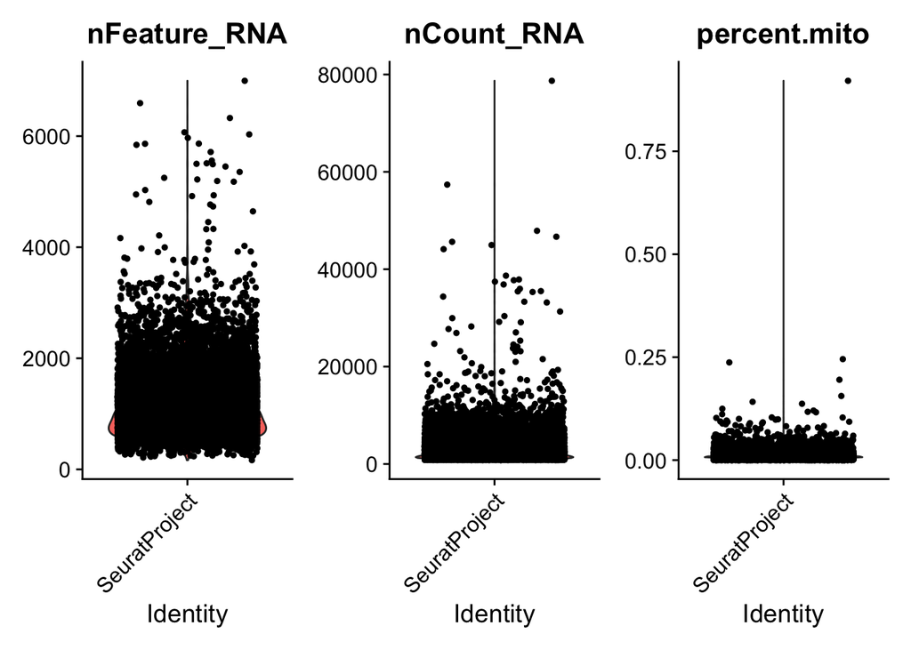

```r
VlnPlot(object = sobj, features = c("nFeature_RNA", "nCount_RNA", "percent.mito"), ncol = 3)
```

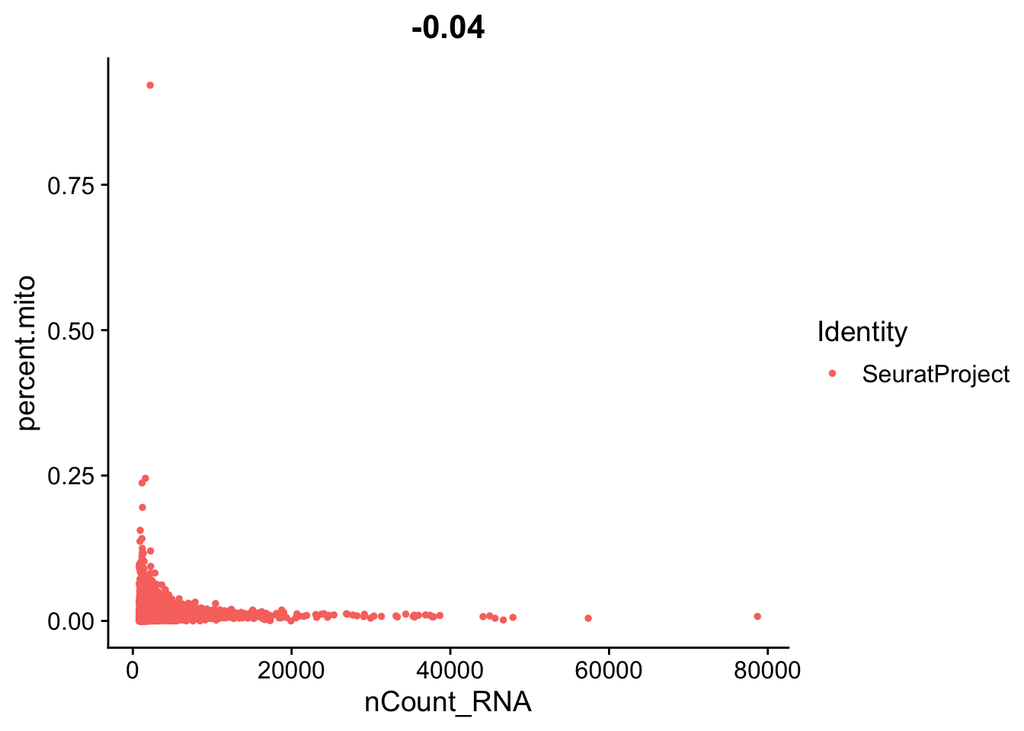

```r
par(mfrow = c(1, 2))
FeatureScatter(object = sobj, feature1 = "nCount_RNA", feature2 = "percent.mito")
```

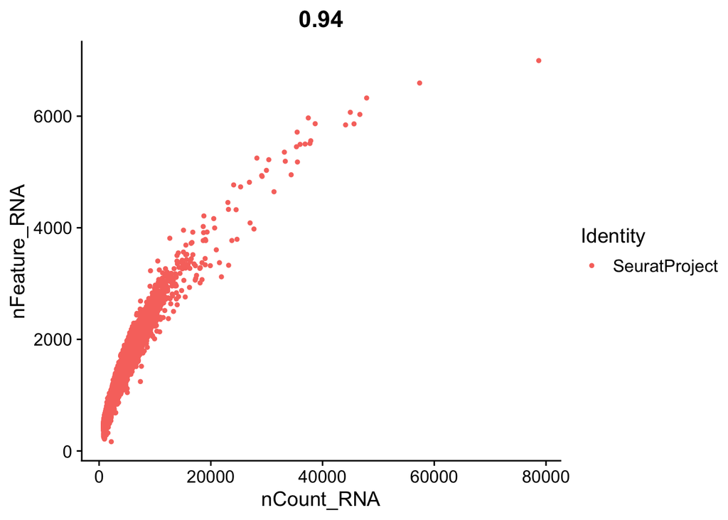

```r
FeatureScatter(object = sobj, feature1 = "nCount_RNA", feature2 = "nFeature_RNA")
```

#### Filtering Cells

We filter out cells that have unique gene counts (nFeature_RNA) over 2,500 or less than 200 Note that > and < are used to define a’gate’.  
-Inf and Inf should be used if you don’t want a lower or upper threshold.

```r
sobj <- subset(x = sobj, subset = nFeature_RNA > 200 & nFeature_RNA < 2500 & percent.mito >  -Inf & percent.mito < 0.05 )
```

#### Log Normalize

After removing unwanted cells from the dataset, the next step is to normalize the data. By default, we employ a global-scaling normalization method “LogNormalize” that normalizes the gene expression measurements for each cell by the total expression, multiplies this by a scale factor (10,000 by default), and log-transforms the result.

```r
sobj <- NormalizeData(object = sobj, normalization.method = "LogNormalize", scale.factor = 10000)
```

### Save Seurat Object

```r
saveRDS(sobj,file="SingleCellCourseSeuratObject.rds")
```